# A Quick Introduction to iNEXT.link via Examples

Anne Chao, K.S. Hu, K.W. Chen, C.G. Lo, S.Y. Wang

2023-08-30

`iNEXT.link` is an R package that extends the concepts of `iNEXT.3D` (Chao et al., 2021), `iNEXT.4step` (Chao et al., 2020) and `iNEXT.beta3D` (Chao et al., 2023) to ecological networks (Chiu et al., 2023). In this document, we provide a brief overview of `iNEXT.link` and its functionalities. Detailed information about the `iNEXT.link` functions can be found in the `iNEXT.link` manual, which is also available on [Github](https://github.com/AnneChao). For users without an R background, an online version (https://chao.shinyapps.io/iNEXT_link/) of `iNEXT.link` is also available.

`iNEXT.link` is primarily designed to calculate and analyze various measures of diversity in ecological networks. Specifically, the package calculates three Hill numbers of order q (species richness, Shannon diversity, and Simpson diversity) in taxonomic diversity level, as well as phylogenetic and functional diversity levels.

For single ecological networks, `iNEXT.link` provides tools for analyzing diversity. The package provides two types of rarefaction and extrapolation (R/E) sampling curves to estimate diversity and confidence intervals for single ecological networks. These include sample-size-based (or size-based) R/E curves and coverage-based R/E curves.

Moreover, `iNEXT.link` offers dissimilarity-turnover curves for the coverage-based R/E curves for gamma, alpha, and beta diversity measures, which can be used to compare diversity patterns across different ecological networks.

## HOW TO CITE iNEXT.link

If you publish your work based on the results from the `iNEXT.link` package, you should make references to the following methodology paper:

- Chiu, C-H., Chao, A., Vogel, S., Kriegel, P. and Thorn, S. (2023). Quantifying and estimating ecological network diversity based on incomplete sampling data. Philosophical Transactions of the Royal Society B, 378: 20220183. https://doi.org/10.1098/rstb.2022.0183

## SOFTWARE NEEDED TO RUN iNEXT.link IN R

- Required: [R](https://cran.r-project.org/)
- Suggested: [RStudio IDE](https://www.rstudio.com/products/RStudio/#Desktop)

## HOW TO RUN iNEXT.link:

The `iNEXT.link` package can be downloaded from Anne Chao’s [iNEXT.link_github](https://github.com/AnneChao/iNEXT.link) using the following commands. For a first-time installation, an additional visualization extension package (`ggplot2`) from CRAN and (`iNEXT.3D`), (`iNEXT.4steps`), and (`iNEXT.beta3D`) from Anne Chao’s github must be installed and loaded.

```r
## install iNEXT.link package from CRAN
# install.packages("iNEXT.link")  # coming soon

## install the latest version from github
install.packages('devtools')
library(devtools)

# install_github('AnneChao/iNEXT.3D')
# install_github('AnneChao/iNEXT.4steps')
# install_github('AnneChao/iNEXT.beta3D')

install_github('AnneChao/iNEXT.link')

## import packages
library(iNEXT.link)
```

## Functions for Single community:

- **iNEXT.link** : Computes rarefaction/extrapolation taxonomic, phylogenetic, and functional diversity estimates and sample coverage estimates.
- **DataInfo.link** : exhibits basic data information
- **estimateD.link** : computes species diversity with a particular user-specified level of sample size or sample coverage.
- **AO.link**: compute asymptotic or empirical(observed) diversity of order q.
- **Completeness.link** : Calculates estimated sample completeness with order q.
- **Spec.link** : Computes standardized specialization estimation under specified sample coverage(or observed) with order q.

## Function for Multi-community:

- **iNEXTbeta.link** : Computing standardized gamma, alpha, beta diversity, and four dissimilarity-turnover indices for three dimensions: taxonomic, phylogenetic and functional diversity at specified sample coverage.

## Functions for Visualizing Results:

- **ggCompleteness.link** : Visualizing the output from the function `Completeness.link`
- **ggSpec.link** : Visualizing the output from the function `Spec.link`
- **ggAO.link** : Visualizing the output from the function `AO.link`
- **ggiNEXT.link** : Visualizing the output from the function `iNEXT.link`
- **ggiNEXTbeta.link** : Visualizing the output from the function `iNEXTbeta.link`

## SINGLE COMMUNITY FUNCTION: iNEXT.link()

We first describe the main function `iNEXT.link()` with default arguments:

```r
iNEXT.link(data,diversity = "TD", q = c(0, 1, 2), size = NULL, nT = NULL,
           endpoint = NULL, knots = 40, conf = 0.95, nboot = 30,
           row.tree = NULL, col.tree = NULL, PDtype = "meanPD",
           row.distM = NULL, col.distM = NULL, FDtype = "AUC", FDtau = NULL)
```

The arguments of this function are briefly described below, and will be explained in more details by illustrative examples in later text.This main function computes diversity estimates of order q, the sample coverage estimates and related statistics for K (if `knots = K`) evenly-spaced knots (sample sizes) between size 1 and the `endpoint`, where the endpoint is described below. Each knot represents a particular sample size for which diversity estimates will be calculated. By default, endpoint = double the reference sample size (total sample size for interaction data (so calles abundance data in iNEXT.3D)). For example, if `endpoint = 10`, `knot = 4`, diversity estimates will be computed for a sequence of samples with sizes (1, 4, 7, 10).

| Argument | Description |
| --- | --- |
| `data` | a list of `data.frames`, each `data.frames` represents col.species-by-row.species abundance matrix. |
| `diversity` | selection of diversity type: `TD` = Taxonomic diversity, `PD` = Phylogenetic diversity, and `FD` = Functional diversity. |
| `q` | a numerical vector specifying the diversity orders. Default is `c(0, 1, 2)`. |
| `size` | an integer vector of sample sizes (number of individuals or sampling units) for which diversity estimates will be computed. If NULL, then diversity estimates will be computed for those sample sizes de… |
| `endpoint` | an integer specifying the sample size that is the endpoint for rarefaction/extrapolation. If NULL, then endpoint = double reference sample size. |
| `knots` | an integer specifying the number of equally-spaced knots between size 1 and the endpoint.Default is 40. |
| `conf` | a positive number < 1 specifying the level of confidence interval. Default is 0.95. |
| `nboot` | a positive integer specifying the number of bootstrap replications when assessing sampling uncertainty and constructing confidence intervals. Enter 0 to skip the bootstrap procedures. Default is 30. |
| `row.tree` | (required only when diversity = “PD” a phylogenetic tree of row assemblage in the pooled network row assemblage. |
| `col.tree` | (required only when diversity = “PD”) a phylogenetic tree of column assemblage in the pooled network column assemblage. |
| `PDtype` | (required only when diversity = “PD”) select PD type: PDtype = “PD” (effective total branch length) or PDtype = “meanPD” (effective number of equally divergent lineages). Default is “meanPD”, where me… |
| `row.distM` | (required only when diversity = “FD”) a species pairwise distance matrix for all species of row assemblage in the pooled network row assemblage. |
| `col.distM` | (required only when diversity = “FD”) a species pairwise distance matrix for all species of column assemblage in the pooled network column assemblage. |
| `FDtype` | (required only when diversity = “FD”), select FD type: FDtype = “tau_values” for FD under specified threshold values, or FDtype = “AUC” (area under the curve of tau-profile) for an overall FD which in… |
| `FDtau` | (required only when diversity = “FD” and FDtype = “tau_values”), a numerical vector between 0 and 1 specifying tau values (threshold levels). If NULL (default), then threshold is set to be the mean di… |

## DATA FORMAT/INFORMATION

Supported Data Types:

Individual-based interaction data : Input data matrix for each assemblage/site include samples species interactions in an empirical sample of n total interactions (“reference sample”). When dealing with N networks, the input data consists of N lists of species interaction matrix.

## RAREFACTION/EXTRAPOLATION VIA EXAMPLES

The data set (tree-beetles interaction data) is included in iNEXT.link package. The experiment took place in the Steigerwald forest in Germany, where deadwood objects from six tree species were exposed in open, net, and closed habitats. In each habitat, there are six plots (A, B, C, D, E, F). Saproxilic beetles were sampled using stem emergence traps and classified according to their functional traits. Data from four years were pooled for each plot and habitat, and pairwise distances were computed from the Gower distance. Here, the demonstration only uses data from plot A in each habitat. For these data, the following commands display the sample species interactions and run the `iNEXT.link()` function for three types of diversty (`"TD"`, `"PD"`, `"FD"` with specified threshold (default is dmean (quadratic entropy)), `"AUC"` which integrates FD from threshold 0 to 1).

Under taxonomic diversity dimension, `iNEXT.link()` function returns including: `$DataInfo` for summarizing data information; `$iNextEst` for showing diversity estimates along with related statistics for a series of rarefied and extrapolated samples; and `$AsyEst` for showing asymptotic diversity estimates along with related statistics. Result under phylogenetic diversity or functional diversity includes these three parts, too.

`$DataInfo` in TD example, as shown below, returns basic data information. It can also be presented using function `DataInfo.link()` to get the same result.

Because the three kinds of diversity output are similar, the demo shows TD only.

```r
linkoutTD = iNEXT.link(data = beetles, diversity = 'TD', q = c(0,1,2), nboot = 30)
linkoutTD$DataInfo
```

```
#>   Networks    n S.obs(row) S.obs(col) Links.obs Connectance Coverage  f1 f2 f3 f4 f5 f6 f7 f8 f9 f10
#> 1   Closed  816          6         83       178      0.3574   0.8800  98 31 15  3  3  5  0  2  2   1
#> 2     Open 1932          6         88       206      0.3902   0.9431 110 33 15  8  7  5  3  2  3   2
```

Second part of output from function `iNEXT.link` is diversity estimates and related statistics computed for these 40 knots by default, which locates the reference sample size at the mid-point of the selected knots. The diversity can be based on sample-size-based and sample coverage-based. The first data frame of list `$iNextEst` (as shown below for ‘size_based’) includes the sample size (`m`), the `Method` (`Rarefaction`, `Observed`, or `Extrapolation`, depending on whether the size `m` is less than, equal to, or greater than the reference sample size), the diversity order (`Order.q`), the diversity estimate of order q (`qD` in TD, `qPD` in PD, `qFD` in FD (under specified thresholds), `qAUC` in FD (area under curve)), the lower and upper confidence limits of diversity (`qD.LCL` and `qD.UCL` in TD, `qPD.LCL` and `qPD.UCL` in PD, `qFD.LCL` and `qFD.UCL` in FD (under specified thresholds), `qAUC.LCL` and `qAUC.UCL` in FD (area under curve)) conditioning on sample size, and the sample coverage estimate (`SC`) along with the lower and upper confidence limits of sample coverage (`SC.LCL`, `SC.UCL`). These sample coverage estimates with confidence intervals are used for plotting the sample completeness curve. It is time consuming for `diversity = FD` and `FDtype = "AUC"`. If the argument `nboot` is greater than zero, then the bootstrap method is applied to obtain the confidence intervals for each diversity and sample coverage estimates.

Here only show first six rows:

```r
head(linkoutTD$iNextEst$size_based)
```

```
#> # A tibble: 6 x 10
#>   Assemblage     m Method      Order.q    qD qD.LCL qD.UCL     SC SC.LCL SC.UCL
#>   <chr>      <dbl> <chr>         <dbl> <dbl>  <dbl>  <dbl>  <dbl>  <dbl>  <dbl>
#> 1 Closed         1 Rarefaction       0   1      1      1   0.0295 0.0259 0.0330
#> 2 Closed        43 Rarefaction       0  28.0   27.1   29.0 0.543  0.515  0.570
#> 3 Closed        86 Rarefaction       0  44.8   42.7   46.8 0.661  0.634  0.688
#> 4 Closed       129 Rarefaction       0  58.2   55.0   61.3 0.713  0.687  0.740
#> 5 Closed       172 Rarefaction       0  69.8   65.6   73.9 0.745  0.720  0.770
#> 6 Closed       215 Rarefaction       0  80.2   75.1   85.4 0.767  0.743  0.791
```

The second data frame of list `$iNextEst` (as shown below for ‘coverage_based’) includes the sample coverage estimate (‘SC’), the sample size (`m`), the `Method` (`Rarefaction`, `Observed`, or `Extrapolation`, depending on whether the size `m` is less than, equal to, or greater than the reference sample size), the diversity order (`Order.q`), the diversity estimate of order q (`qD` in TD, `qPD` in PD, `qFD` in FD (under specified thresholds), `qAUC` in FD (area under curve)), the lower and upper confidence limits of diversity (`qD.LCL` and `qD.UCL` in TD, `qPD.LCL` and `qPD.UCL` in PD, `qFD.LCL` and `qFD.UCL` in FD (under specified thresholds), `qAUC.LCL` and `qAUC.UCL` in FD (area under curve)) conditioning on sample coverage estimate.

Here only show first six rows:

```r
head(linkoutTD$iNextEst$coverage_based)
```

```
#> # A tibble: 6 x 8
#>   Assemblage     SC      m Method      Order.q    qD qD.LCL qD.UCL
#>   <chr>       <dbl>  <dbl> <chr>         <dbl> <dbl>  <dbl>  <dbl>
#> 1 Closed     0.0295   1.00 Rarefaction       0  1.00  0.965   1.04
#> 2 Closed     0.543   43.0  Rarefaction       0 28.0  24.7    31.4
#> 3 Closed     0.661   86.0  Rarefaction       0 44.8  38.2    51.3
#> 4 Closed     0.713  129.   Rarefaction       0 58.2  48.8    67.6
#> 5 Closed     0.745  172.   Rarefaction       0 69.8  57.9    81.7
#> 6 Closed     0.767  215.   Rarefaction       0 80.2  66.1    94.4
```

The output `$AsyEst` lists the diversity labels (`Diversity` in TD, `Phylogenetic Diversity` in PD, `Functional Diversity` in FD), the observed diversity (`Observed` in TD, `Phylogenetic Observed` in PD, `Functional Observed` in FD), asymptotic diversity estimates (`Estimator` in TD, `Phylogenetic Estimator` in PD, `Functional Estimator` in FD), estimated bootstrap standard error (`s.e.`) and confidence intervals for diversity with q = 0, 1, and 2 (`LCL`, `UCL`). The estimated asymptotic and observed diversity can also be computed via the function `AO.link()`. The output are shown below:

Here only show first six rows:

```r
head(linkoutTD$AsyEst)
```

```
#>   Assemblage         Diversity   Observed  Estimator       s.e.        LCL       UCL
#> 1     Closed  Species richness 178.000000 332.713393 30.4341711 273.063514 392.36327
#> 2     Closed Shannon diversity  64.690053  80.316088  4.1690244  72.144950  88.48723
#> 3     Closed Simpson diversity  32.627205  33.944467  2.1213475  29.786702  38.10223
#> 4       Open  Species richness 206.000000 389.238440 32.1188744 326.286603 452.19028
#> 5       Open Shannon diversity  23.311453  25.911799  1.6682978  22.641996  29.18160
#> 6       Open Simpson diversity   8.059978   8.089554  0.3963828   7.312658   8.86645
```

## GRAPHIC DISPLAYS: FUNCTION ggiNEXT.link()

The function `ggiNEXT.link()`, which extends `ggplot2` with default arguments, is described as follows:

```r
ggiNEXT.link(outcome, type = 1:3, facet.var = "Assemblage", color.var = "Order.q")
```

Here `outcome` is the object of `iNEXT.link()`’s output. Three types of curves are allowed for different diversity dimensions:

1. Sample-size-based R/E curve (`type = 1`): This curve plots diversity estimates with confidence intervals as a function of sample size.
2. Sample completeness curve (`type = 2`): This curve plots the sample coverage with respect to sample size.
3. Coverage-based R/E curve (`type = 3`): This curve plots the diversity estimates with confidence intervals as a function of sample coverage.

The argument `facet.var = "Order.q"` or `facet.var = "Assemblage"` is used to create a separate plot for each value of the specified variable. For example, the following code displays a separate plot of the diversity order q. The `ggiNEXT.link()` function is a wrapper with package `ggplot2` to create a R/E curve in a single line of code. The figure object is of class `"ggplot"`, so can be manipulated by using the `ggplot2` tools.

When `facet.var = "Assemblage"` in `ggiNEXT.link` function, it creates a separate plot for each network and the different color lines represent each diversity order. Sample-size-based R/E curve (`type = 1`) as below:

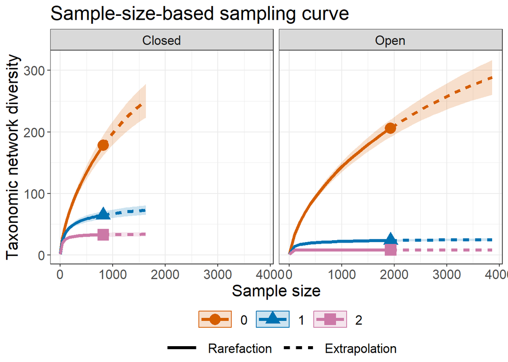

```r
# Sample-size-based R/E curves, separating by "assemblage""
ggiNEXT.link(linkoutTD, type = 1, facet.var = "Assemblage")
```

When `facet.var = "Order.q"` in `ggiNEXT.link` function, it creates a separate plot for each diversity order and the different color lines represent each network. Sample-size-based R/E curve (`type = 1`) as below:

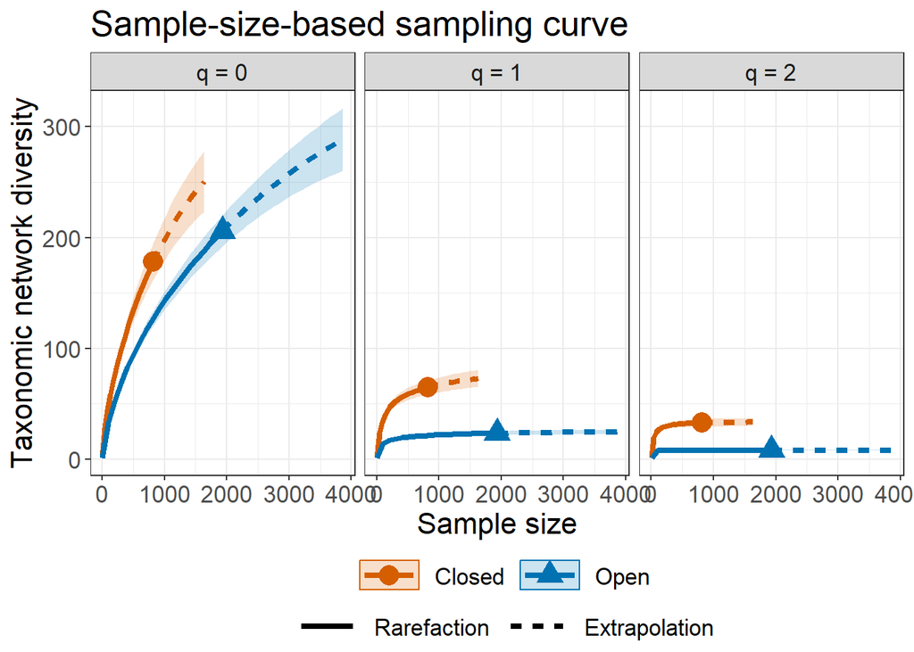

```r
# Sample-size-based R/E curves, separating by "Order.q"
ggiNEXT.link(linkoutTD, type = 1, facet.var = "Order.q")
```

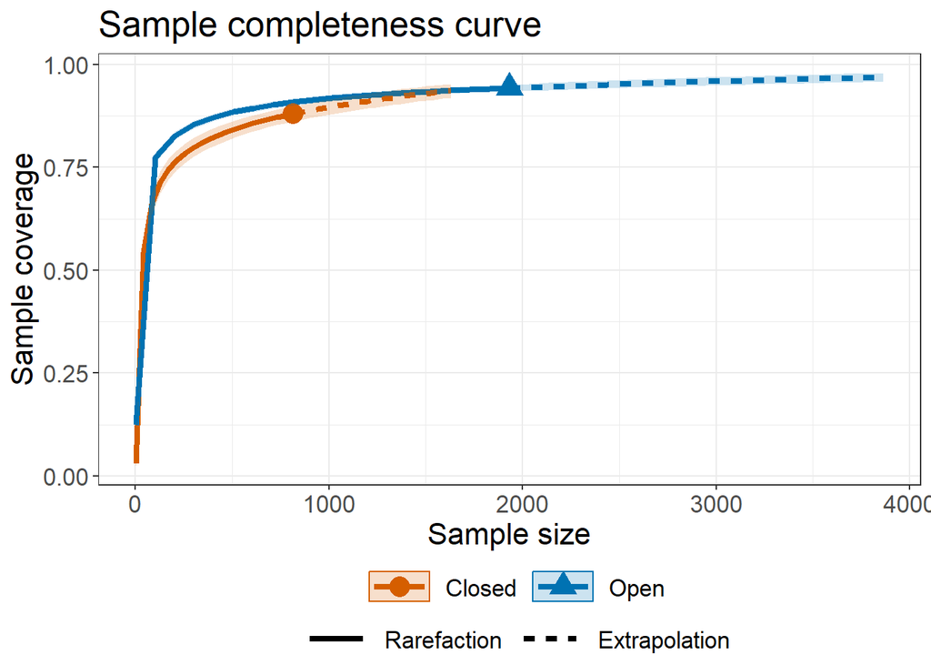

```r
ggiNEXT.link(linkoutTD, type = 2, facet.var = "Order.q", color.var = "Assemblage")
```

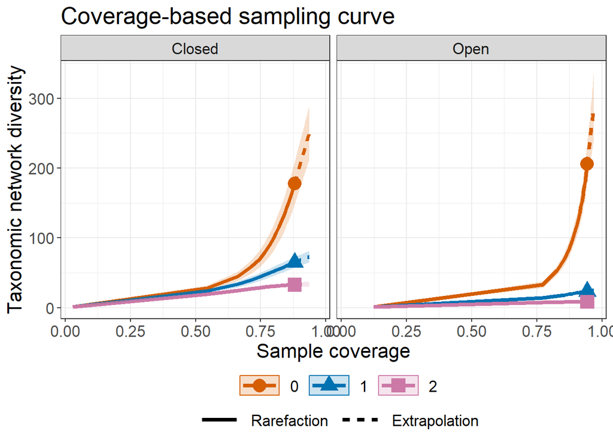

```r
ggiNEXT.link(linkoutTD, type = 3, facet.var = "Assemblage")
```

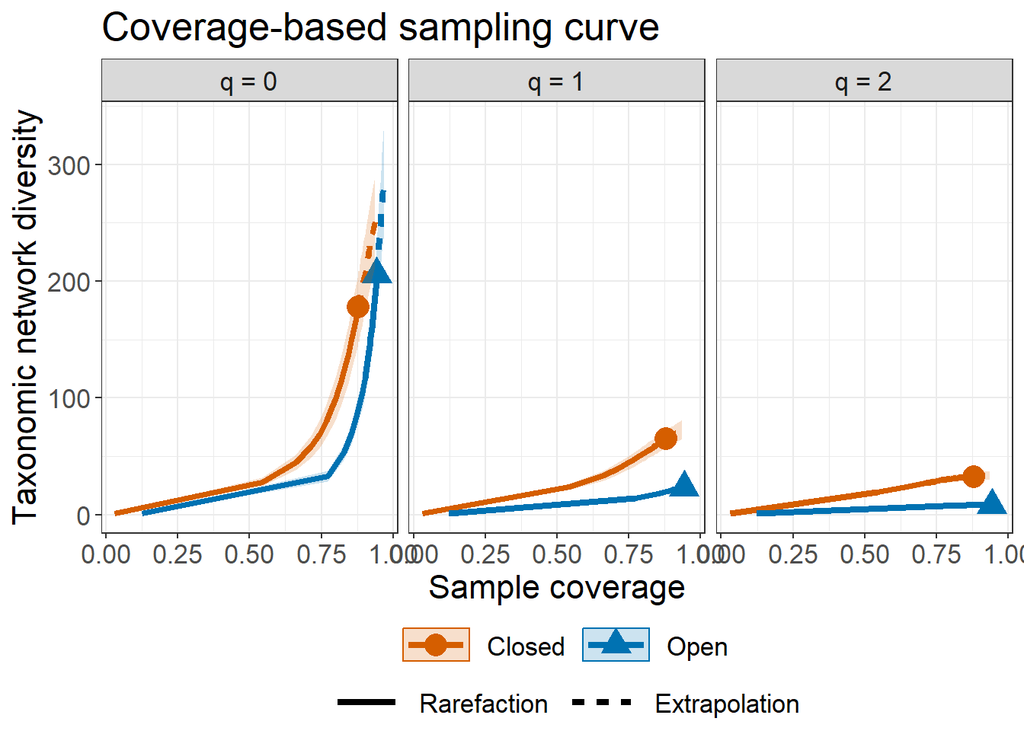

```r
ggiNEXT.link(linkoutTD, type = 3, facet.var = "Order.q")
```

## DATA INFORMATION FUNCTION: DataInfo.link()

```r
DataInfo.link(data, diversity = "TD", row.tree = NULL,
              col.tree = NULL, row.distM = NULL, col.distM = NULL)
```

Here provide the function `DataInfo.link` to compute three diversity dimensions (‘TD’, ‘PD’, ‘FD’) data information, which including sample size, observed species richness, sample coverage estimate, and the first ten interaction frequency counts when `diversity = TD`. And so on for PD, FD.

```r
DataInfo.link(beetles, diversity = 'TD')
```

```
#>   Networks    n S.obs(row) S.obs(col) Links.obs Connectance Coverage  f1 f2 f3 f4 f5 f6 f7 f8 f9 f10
#> 1   Closed  816          6         83       178      0.3574   0.8800  98 31 15  3  3  5  0  2  2   1
#> 2     Open 1932          6         88       206      0.3902   0.9431 110 33 15  8  7  5  3  2  3   2
```

```r
DataInfo.link(beetles, diversity = 'PD', col.tree = beetles_col_tree)
```

```
#>   Networks    n S.obs(row) S.obs(col) Links.obs Connectance f1* f2*       g1       g2 PD.obs mean_T
#> 1   Closed  816          6         83       178      0.3574  98  31 11508.99 3873.052    924    285
#> 2     Open 1932          6         88       206      0.3902 110  33 13918.45 5172.410   1014    285
```

```r
DataInfo.link(beetles, diversity = 'FD', col.distM = beetles_col_distM)
```

```
#>   Networks    n S.obs(row) S.obs(col) Links.obs Connectance  f1 f2 a1' a2' threshold
#> 1   Closed  816          6         83       178      0.3574  98 31   0   0  8.930741
#> 2     Open 1932          6         88       206      0.3902 110 33   0   0  8.021019
```

## POINT ESTIMATION FUNCTION: estimateD.link()

```r
estimateD.link(data, diversity = "TD", q = c(0, 1, 2),
               base = "coverage", level = NULL, nboot = 50, conf = 0.95,
               PDtype = "meanPD", row.tree = NULL, col.tree = NULL, row.distM = NULL,
               col.distM = NULL, FDtype = "AUC", FDtau = NULL)
```

`estimateD.link` is used to compute three diversity dimensions (TD, PD, FD) estimates with q = 0, 1, 2 under any specified level of sample size (when `base = "size"`) or sample coverage (when `base = "coverage"`). If `level = NULL`, this function computes the diversity estimates for the minimum sample size among all samples extrapolated to double reference sizes (when `base = "size"`) or the minimum sample coverage among all samples extrapolated to double reference sizes (when `base = "coverage"`).

```r
estimateD.link(beetles, diversity = 'TD', q = c(0, 1, 2), base = "coverage", level = 0.95)
```

```
#>   Assemblage   SC        m        Method Order.q         qD       s.e.    qD.LCL     qD.UCL
#> 1     Closed 0.95 1944.292 Extrapolation       0 268.252103 31.6119477 206.29382 330.210382
#> 2     Closed 0.95 1944.292 Extrapolation       1  74.577021  4.7352505  65.29610  83.857942
#> 3     Closed 0.95 1944.292 Extrapolation       2  33.378889  1.9452047  29.56636  37.191420
#> 4       Open 0.95 2349.132 Extrapolation       0 228.271774 18.3541152 192.29837 264.245178
#> 5       Open 0.95 2349.132 Extrapolation       1  23.704215  1.0131717  21.71843  25.689995
#> 6       Open 0.95 2349.132 Extrapolation       2   8.065214  0.2492206   7.57675   8.553677
```

## ASYMPTOTIC AND EMPIRICAL (OBSERVED) DIVERSITY FUNCTION: AO.link

```r
AO.link(data, diversity = "TD", q = seq(0, 2, 0.2),  nboot = 30,
        conf = 0.95, method = c("Asymptotic", "Observed"),
        row.tree = NULL, col.tree = NULL, PDtype = "meanPD", row.distM = NULL,
        col.distM = NULL, FDtype = "AUC", FDtau = NULL)
```

```r
out1 <- AO.link(beetles, diversity = 'TD', q = seq(0, 2, 0.2), method = c("Asymptotic", "Observed"),
                nboot = 5,conf = 0.95)

out1
```

```
#>    Order.q         qD       s.e.     qD.LCL     qD.UCL Network     Method
#> 1      0.0 332.713393 49.7613980 284.602826 402.506774  Closed Asymptotic
#> 2      0.2 265.977501 36.0904018 230.075727 317.589230  Closed Asymptotic
#> 3      0.4 203.167245 24.5267835 178.674263 238.752957  Closed Asymptotic
#> 4      0.6 149.540048 15.8846271 134.358603 173.104278  Closed Asymptotic
#> 5      0.8 108.592546 10.1994677  99.623634 123.690228  Closed Asymptotic
#> 6      1.0  80.316088  6.7979355  74.421521  90.102840  Closed Asymptotic
#> 7      1.2  61.983531  4.8409078  57.087812  68.652169  Closed Asymptotic
#> 8      1.4  50.295815  3.7052606  46.273786  55.141042  Closed Asymptotic
#> 9      1.6  42.699384  3.0244122  39.308294  46.430473  Closed Asymptotic
#> 10     1.8  37.568079  2.6010586  34.613649  40.572396  Closed Asymptotic
#> 11     2.0  33.944467  2.3298159  31.302419  36.442804  Closed Asymptotic
#> 12     0.0 389.238440 62.9493691 335.841027 484.084125    Open Asymptotic
#> 13     0.2 263.223968 38.5269493 228.400698 320.491399    Open Asymptotic
#> 14     0.4 159.174040 19.7810791 140.051106 188.051259    Open Asymptotic
```

[output cut: 30 more lines]

## GRAPHIC DISPLAYS FUNCTION: ggAO.link()

```r
ggAO.link(outcome)
```

`ggAO.link()` plots q-profile based on `ggplot2`. Here `outcome` is the object from the function `AO.link`.

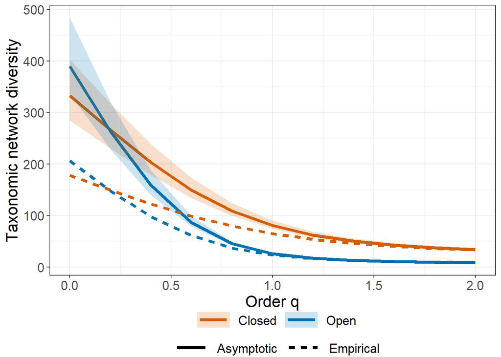

```r
# q profile curve
ggAO.link(out1)
```

## SINGLE COMMUNITY FUNCTION: Completeness.link()

Function `Completeness.link()` provides a easy way to compute estimated sample completeness with order q. The arguments is below:

```r
Completeness.link(data, q = seq(0, 2, 0.2), nboot = 30, conf = 0.95)
```

| Argument | Description |
| --- | --- |
| `data` | a `list` of `data.frames`, each `data.frames` represents col.species-by-row.species abundance matrix. |
| `q` | a numerical vector specifying the diversity orders. Default is (0, 0.2, 0.4,…, 2). |
| `nboot` | a positive integer specifying the number of bootstrap replications when assessing sampling uncertainty and constructing confidence intervals. Bootstrap replications are generally time consuming. Enter… |
| `conf` | a positive number < 1 specifying the level of confidence interval. Default is `0.95`. |

## GRAPHIC DISPLAYS FUNCTION: ggCompleteness.link()

We also provides a realized function `ggCompleteness.link` to plot the output from `Completeness.link()`:

```r
ggCompleteness.link(output)
```

| Argument | Description |
| --- | --- |
| `output` | a table generated from function `Completeness.link`. |

Use data beetles to calculate sample completeness and plot it.

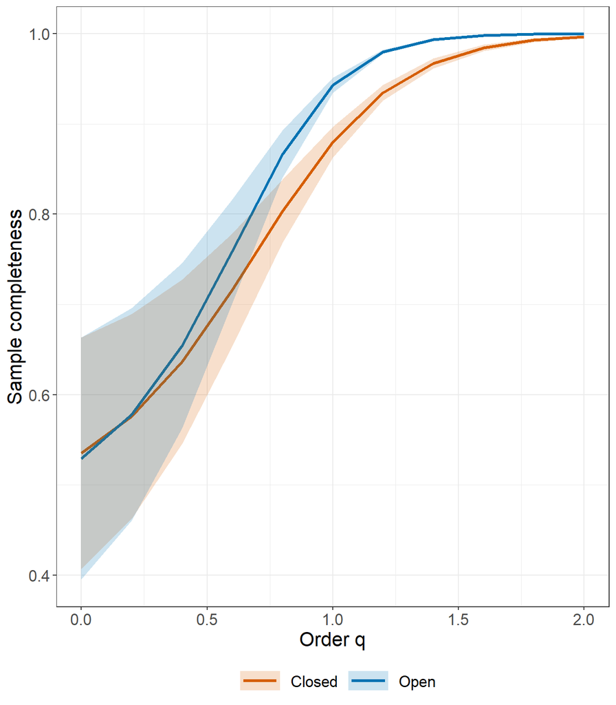

```r
out1 <- Completeness.link(data = beetles)
ggCompleteness.link(out1)
```

## SINGLE COMMUNITY FUNCTION: Spec.link()

The main function `Spec.link()` with default arguments:

```r
Spec.link(data, q = seq(0, 2, 0.2), method = "Estimated",
         nboot = 30, conf = 0.95, E.class = c(1:5), C = NULL)
```

| Argument | Description |
| --- | --- |
| `data` | a `list` of `data.frames`, each `data.frames` represents col.species-by-row.species abundance matrix. |
| `q` | a numerical vector specifying the diversity orders. Default is (0, 0.2, 0.4,…, 2). |
| `method` | a binary calculation method with ‘Estimated’ or ‘Observed’. |
| `nboot` | a positive integer specifying the number of bootstrap replications when assessing sampling uncertainty and constructing confidence intervals. Bootstrap replications are generally time consuming. Enter… |
| `conf` | a positive number < 1 specifying the level of confidence interval. Default is `0.95`. |
| `E.class` | an integer vector between 1 to 5. There are five transformation for evenness in Chao and Ricotta (2019). Default is 1:5. |
| `C` | a standardized coverage for calculating evenness index. It is used when `method = 'Estimated'`. If `NULL`, then this function computes the diversity estimates for the minimum sample coverage among all… |

## GRAPHIC DISPLAYS FUNCTION: ggSpec.link()

The function `ggSpec.link()` is provided to plot the output from `Spec.link()`.

```r
ggSpec.link(output)
```

| Argument | Description |
| --- | --- |
| `output` | a table generated from function `Spec.link`. |

There is an example for function `Spec.link` and function `ggSpec.link`.

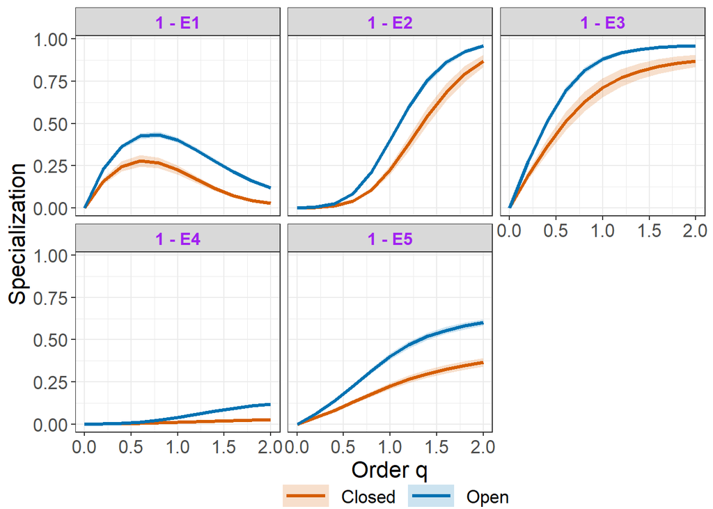

```r
out1 <- Spec.link(data = beetles)
ggSpec.link(out1)
```

## MULTI-COMMUNITIES FUNCTION: iNEXTbeta.link()

```r
iNEXTbeta.link(data, diversity = "TD", level = seq(0.5, 1, 0.05),
               q = c(0, 1, 2), nboot = 20, conf = 0.95,
               PDtype = "meanPD", row.tree = NULL, col.tree = NULL, row.distM = NULL,
               col.distM = NULL, FDtype = "AUC", FDtau = NULL, FDcut_number = 30)
```

The arguments of this function are briefly described below, and will be explained in more details by illustrative examples in later text. This main function computes gamma, alpha and beta diversity estimates of order q at specified sample coverage and measures of dissimilarity. By default of `base = “coverage”` and `level = NULL`, then this function computes the gamma, alpha, beta diversity, and four dissimilarity-turnover indices estimates up to one (for q = 1, 2) or up to the coverage of double the reference sample size (for q = 0).

| Argument | Description |
| --- | --- |
| `data` | data can be input as a list} of data.frame, each data.frame represents col.species-by-row.species abundance matrix |
| `diversity` | selection of diversity type: `TD` = Taxonomic diversity, `PD` = Phylogenetic diversity, and `FD` = Functional diversity. |
| `level` | a sequence specifying the particular sample coverages (between 0 and 1). Default is `seq(0.5, 1, 0.05)`. |
| `q` | a numerical vector specifying the diversity orders. Default is `c(0, 1, 2)`. |
| `nboot` | a positive integer specifying the number of bootstrap replications when assessing sampling uncertainty and constructing confidence intervals. Bootstrap replications are generally time consuming. Enter… |
| `conf` | a positive number < 1 specifying the level of confidence interval. Default is `0.95`. |
| `PDtype` | (required only when `diversity = “PD”`), select PD type: `PDtype = “PD”` (effective total branch length) or `PDtype = “meanPD”` (effective number of equally divergent lineages). Default is `“meanPD”`. |
| `row.tree` | (required only when `diversity = “PD”`), a phylogenetic tree of row assemblage in the pooled network row assemblage. |
| `col.tree` | (required only when `diversity = “PD”`), a phylogenetic tree of column assemblage in the pooled network column assemblage. |
| `row.disM` | (required only when `diversity = “FD”`), a species pairwise distance matrix for all species of row assemblage in the pooled network row assemblage. |
| `col.disM` | (required only when `diversity = “PD”`), a species pairwise distance matrix for all species of column assemblage in the pooled network column assemblage. |
| `FDtype` | (required only when `diversity = “FD”`), select FD type: `FDtype = “tau_value”` for FD under a specified threshold value, or `FDtype = “AUC”` (area under the curve of tau-profile) for an overall FD wh… |
| `FDtau` | (required only when `diversity = “FD”` and FDtype = “tau_value” ), a numerical value between 0 and 1 specifying the tau value (threshold level). If `NULL` (default), then threshold is set to be the me… |

the `iNEXTbeta.link()` function returns the `"iNEXTbeta.link"` object including seven data frames for each regions:

- gamma
- alpha
- beta
- C ( Sorensen-type non-overlap )
- U ( Jaccard-type non-overlap )
- V ( Sorensen-type turnover )
- S ( Jaccard-type turnover )

Here only show the first six rows in each table output:

```r
# Taxonomic diversity
Abundance_TD = iNEXTbeta.link(data = beetles, diversity = 'TD', level = NULL, q = c(0, 1, 2))
Abundance_TD
```

[output not shown]

The output contains seven data frames: `gamma`, `alpha`, `beta`, `C`, `U`, `V`, `S`. For each data frame, it includes the diversity estimate (`Estimate`), the diversity order (`Order.q`), `Method` (Rarefaction, Observed, or Extrapolation, depending on whether the size `m` is less than, equal to, or greater than the reference sample size), the sample coverage estimate (`SC`), the sample size (`Size`), the standard error from bootstrap replications (`s.e.`), the lower and upper confidence limits of diversity (`LCL`, `UCL`), and the name of region (`Region`). These diversity estimates with confidence intervals are used for plotting the diversity curve.

## GRAPHIC DISPLAYS FUNCTION: ggiNEXTbeta.link()

The function `ggiNEXTbeta.link()`, which extends `ggplot2` to the `"iNEXT.link"` object with default arguments, is described as follows:

| Argument | Description |
| --- | --- |
| `output` | the output of `iNEXTbeta.link`. |
| `type` | selection of plot type : type = ‘B’ for plotting the gamma, alpha, and beta diversity; type = ‘D’ for plotting 4 turnover dissimilarities. |
| `scale` | Are scales shared across all facets (the default, `“fixed”`), or do they vary across rows (`“free_x”`), columns (`“free_y”`), or both rows and columns (`“free”`)? Default is `“free”`. |

The `ggiNEXTbeta.link()` function is a wrapper around the `ggplot2` package to create a R/E curve using a single line of code. The resulting object is of class `"ggplot"`, so it can be manipulated using the `ggplot2` tools. Users can visualize the output of beta diversity or four dissimilarities by setting the parameter `type`:

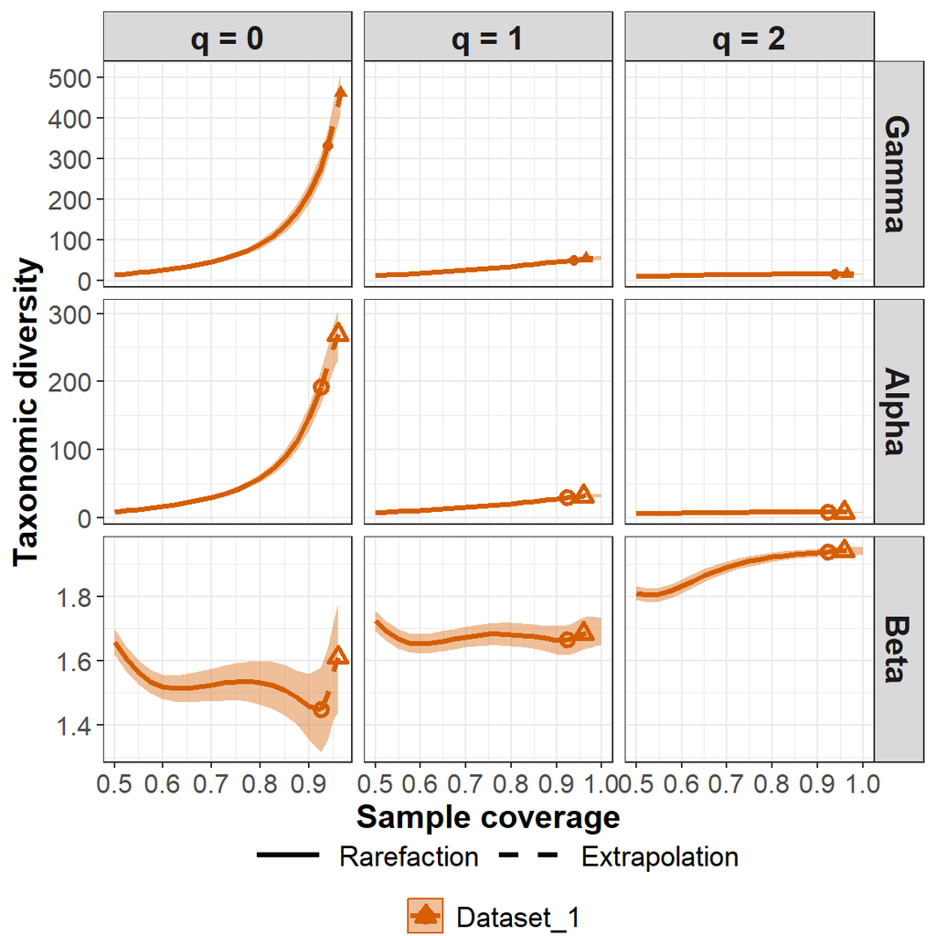

```r
ggiNEXTbeta.link(Abundance_TD, type = 'B')
```

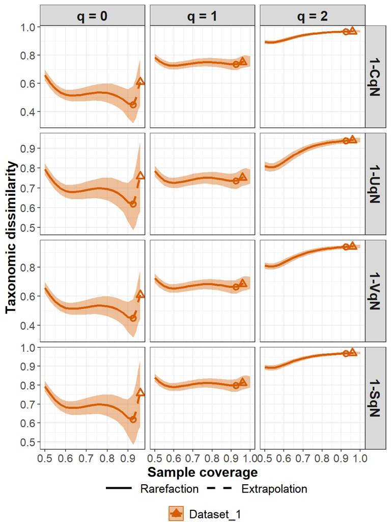

```r
ggiNEXTbeta.link(Abundance_TD, type = 'D')
```

## License

The iNEXT.link package is licensed under the GPLv3. To help refine `iNEXT.link`, your comments or feedback would be welcome (please send them to Anne Chao or report an issue on the iNEXT.link github [iNEXT.link_github](https://github.com/AnneChao/iNEXT.link).